# Práctica 2. Extracción, y posterior visualización de valores de temperatura en localidades concretas.

En esta práctica se utilizarán los archivos de temeratura mínima y precipitación de Aragón correspondientes a los años 1980 y 2018. Posteriormente se generarán nuevas variables, se extraerán los valores para unas localidades concretas y se visualizarán los resultados.

Cargar las librerías.

```r
library(raster)
library(ggplot2)
library(reshape2)
library(ggpubr)
```

**Cargar archivos vectoriales**

```r
PA <- shapefile("E:/SEMINARIO_BIOGEOGRAFIA/VECTORIAL/AP/AP_spain.shp")
Aragon <- shapefile("E:/SEMINARIO_BIOGEOGRAFIA/VECTORIAL/ARAGON/Aragon.shp")
puntos <- shapefile("E:/SEMINARIO_BIOGEOGRAFIA/VECTORIAL/PUNTOS/puntos.shp")
```

Sistemas de referencia.

```r
proj4string(PA)
```

```
## [1] "+proj=utm +zone=30 +ellps=GRS80 +towgs84=0,0,0,0,0,0,0 +units=m +no_defs"
```

```r
proj4string(Aragon)
```

```
## [1] "+proj=longlat +ellps=GRS80 +no_defs"
```

```r
proj4string(puntos)
```

```
## [1] "+proj=utm +zone=30 +ellps=GRS80 +towgs84=0,0,0,0,0,0,0 +units=m +no_defs"
```

Modificar sistema de referencia.

```r
Aragon <- spTransform(Aragon, CRS("+init=epsg:25830"))
```

Visualizar los datos a utilizar.

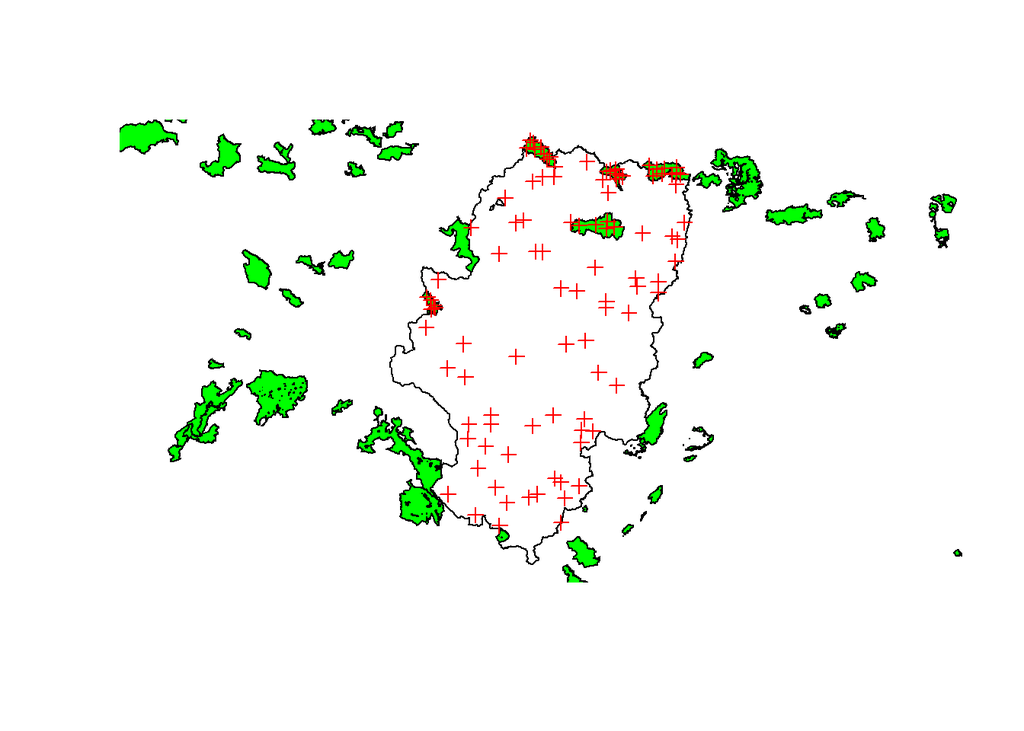

```r
plot(Aragon)
plot(PA, col = "green", add= T)
plot(puntos, col = "red", add= T)
```

Extraer información.

```r
PA_Aragon <- raster::intersect(Aragon, PA)
puntos_PA_aragon <- raster::intersect(puntos, PA_Aragon)
```

Visualizar los nuevos datos generados.

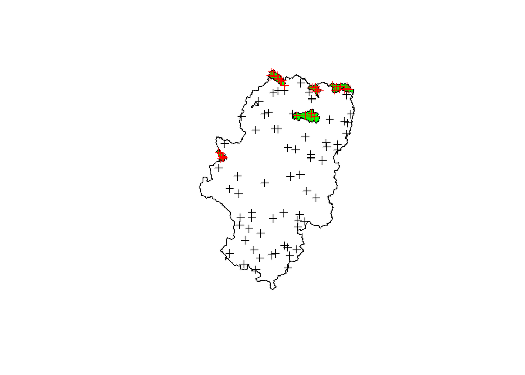

```r
plot(Aragon)
plot(PA_Aragon, col = "green", add= T)
plot(puntos, col = "black", add= T)
plot(puntos_PA_aragon, col = "red", add= T)
```

**Obtener la temperatura minima promedio anual para Aragón.**  
De manera individual:  
Mediante la función `list.files` buscar los archivos que coincidan con el año indicado en `pattern`.

```r
nombres <- list.files("E:/SEMINARIO_BIOGEOGRAFIA/RASTER/ARAGON/TEMPERATURA_MINIMA/",
                      pattern = "1980" ,
                      full.names = TRUE)
```

Con la función `stack` se agrupan en un mismo objeto todos los archivos seleccionados en el objeto nombre.

```r
Temperatura_minima <- stack(nombres)
```

Mediante la función `calc` se genra un nuevo raster promedio (mean) de todos los raster que componen el stack.

```r
Temperatura_minima_anual <- calc(Temperatura_minima, mean)
```

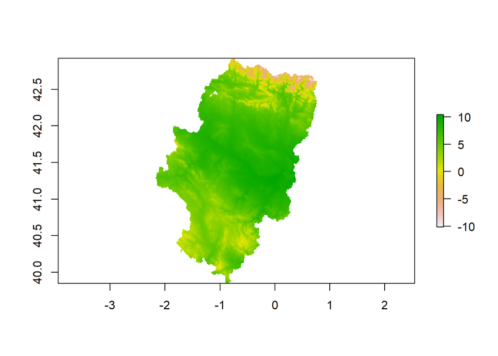

```r
plot(Temperatura_minima_anual)
```

Para varios años:  
Para hacer esto de manera automática es necesario hacerlo mediante un bucle que itere sobre los diferentes años.  
El primer paso es crear un stack vacio donde se almacenarán los resultados.

```r
Temperatura_minima_anual <- raster::stack()
```

Mediante el bucle se ejecutará el mismo proceso cambiando diferentes años (llamados `i`) y se irán guardando en el stack vacio `Temperatura_minima_anual` creado.

```r
for (i in c(1980, 2018)){
  nombres <- list.files("E:/SEMINARIO_BIOGEOGRAFIA/RASTER/ARAGON/TEMPERATURA_MINIMA/",
                        pattern = paste0(i) ,
                        full.names = TRUE)
  Temperatura_minima <- stack(nombres)
  Temperatura_minima <- calc(Temperatura_minima, mean)
  Temperatura_minima_anual <- raster::stack(Temperatura_minima_anual, Temperatura_minima)
}
```

El último paso sería modificar los nombres de los diferentes rasters generados.

```r
names(Temperatura_minima_anual) <- c("TMIN_1980", "TMIN_2018")
```

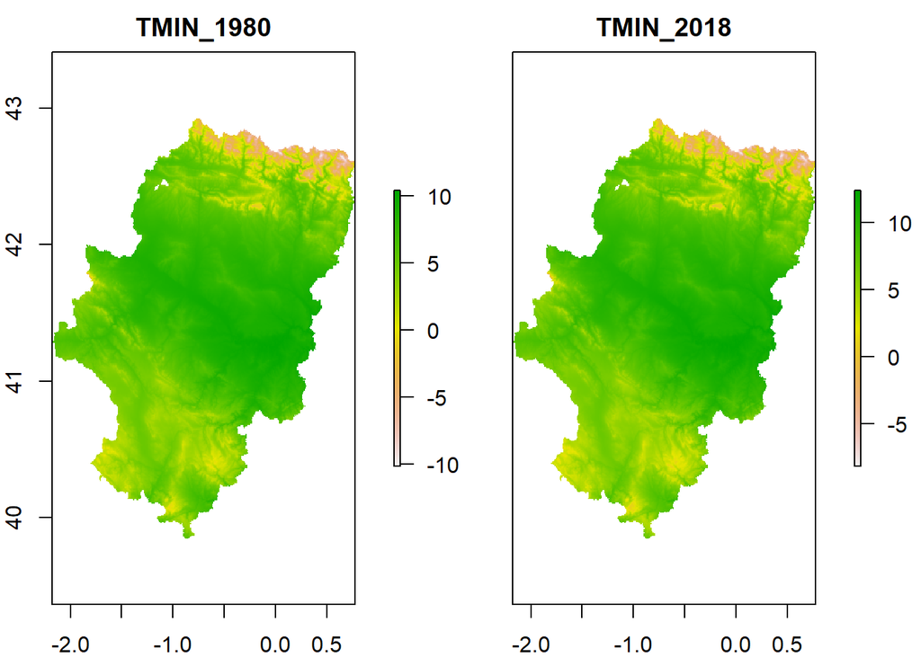

```r
plot(Temperatura_minima_anual)
```

Hacemos lo mismo para la precipitación.

```r
Precipitacion_anual <- raster::stack()
for (i in c(1980, 2018)){
  nombres <- list.files("E:/SEMINARIO_BIOGEOGRAFIA/RASTER/ARAGON/PRECIPITACION/",
                        pattern = paste0(i),
                        full.names = TRUE)
  Precipitacion <- stack(nombres)
  Precipitacion <- calc(Precipitacion, sum)
  Precipitacion <- Precipitacion / 10
  Precipitacion_anual <- raster::stack(Precipitacion_anual, Precipitacion)
}

names(Precipitacion_anual) <- c("PR_1980", "PR_2018")
```

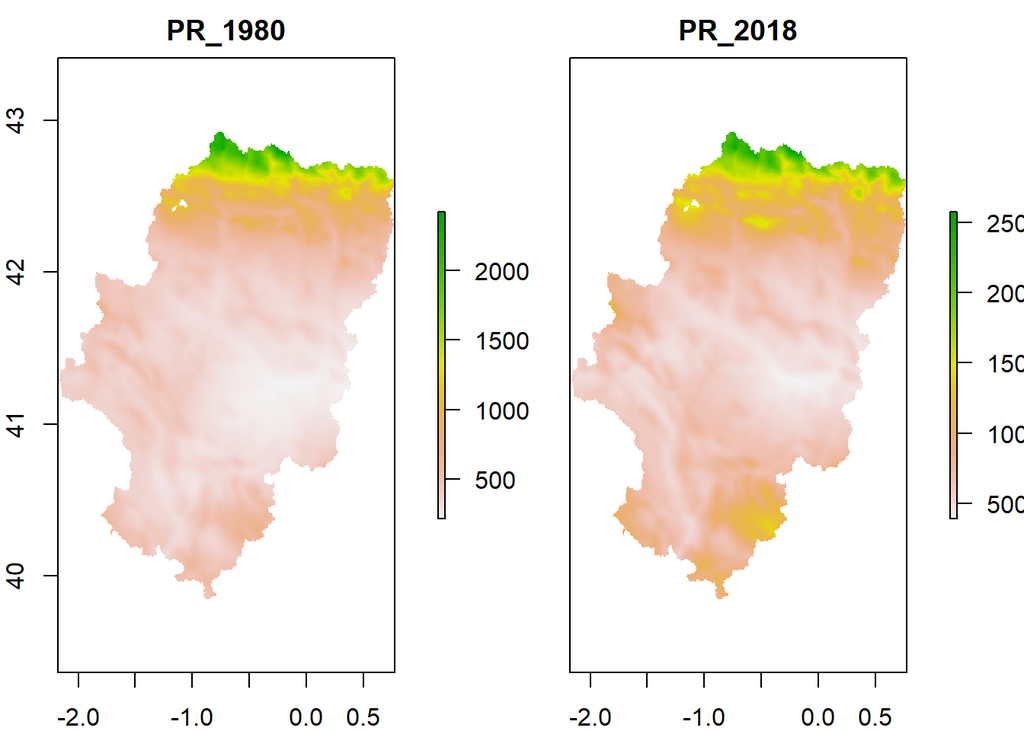

```r
plot(Precipitacion_anual)
```

**Extracccion de datos raster utilizando un archivo vectorial**  
Para ello, primero extraemos la temperatura, después añadimos la información existente en la tabla de atributos y las coordenadas de los puntos.  
Temperatura:

```r
Temperatura_minima_anual_PA <- extract(Temperatura_minima_anual, puntos_PA_aragon, fun = mean, df = T)
Temperatura_minima_anual_PA <-  cbind(Temperatura_minima_anual_PA, puntos_PA_aragon@data, coordinates(puntos_PA_aragon))
```

Precipitación:

```r
Precipitacion_anual_PA <- extract(Precipitacion_anual, puntos_PA_aragon, fun = mean, df = T)
Precipitacion_anual_PA <- cbind(Precipitacion_anual_PA, puntos_PA_aragon@data, coordinates(puntos_PA_aragon))
```

Limpiamos los dos marcos de datos para trabajar más comodamente.

```r
Temperatura_minima_anual_PA <- Temperatura_minima_anual_PA[,c(12,11, 2,3)]
Precipitacion_anual_PA <- Precipitacion_anual_PA[,c(12,11, 2,3)]
```

**Graficos**  
En esta sección vamos a ver como realizar unos gráficos sencillos para visualizar los resultados.  
Utilizaremos el paquete `ggplot`. Con este paquete se pueden hacer mapas también. Como primer paso, y debido al tipo de gráfico que se realizará, utilizamos la función `melt` del paquete `reshape2`. Esta función organiza los valores de datos en un formato de marco de datos largo.

```r
Temperatura_minima_anual_PA <- reshape2::melt(Temperatura_minima_anual_PA)
Precipitacion_anual_PA <- reshape2::melt(Precipitacion_anual_PA)
```

Visualizar  
Un gráfico con `ggplot` se construye a partir de algunos elementos básicos:

Datos: los datos para graficar.  
Geometrías `geom_`: las formas geométricas que se quieren representar.  
Estética `aes()`: estética de los objetos geométricos y estadísticos, como posición, color, tamaño, forma y transparencia.  
Escalas `scale_`: relación entre los datos y las dimensiones estéticas, como el ancho o los valores para los colores.  
Temas visuales `theme()`: los valores visuales generales de un gráfico, como el fondo, las cuadrículas, los ejes, el tipo de letra predeterminado, los tamaños y los colores.

El gráfico mas sencillo para ver si hay diferencias entre periodos sería un diagrama de cajas.

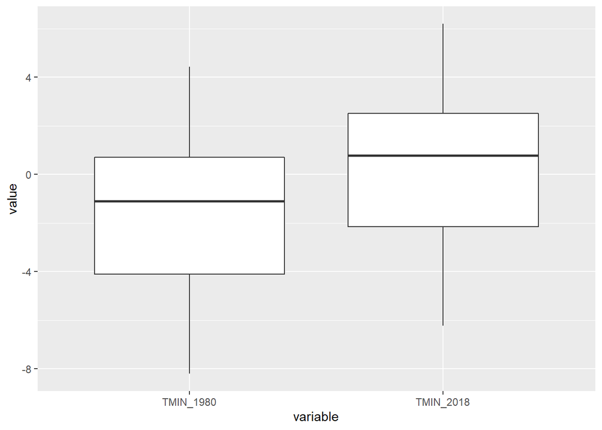

```r
ggplot(Temperatura_minima_anual_PA,
       aes(x = variable,
           y = value)) +
  geom_boxplot()
```

Este mismo gráfico puede modificarse de muchas maneras.  
Un ejemplo:

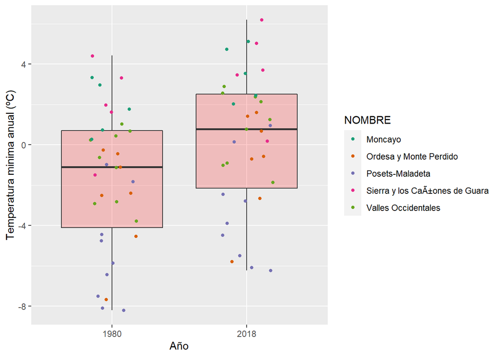

```r
ggplot(Temperatura_minima_anual_PA, aes(x = variable, y = value)) +
  geom_boxplot(fill ="red", alpha = .2,)+
  geom_point(aes(col= NOMBRE), position = position_jitter(width = .2),
             size = 2,
             shape = 20)+
  scale_x_discrete(labels= c("1980", "2018"))+
  scale_colour_brewer(palette = "Dark2")+
  labs(y = "Temperatura minima anual (ºC)", x = "Año")+
  theme_grey()
```

Otro ejempo:

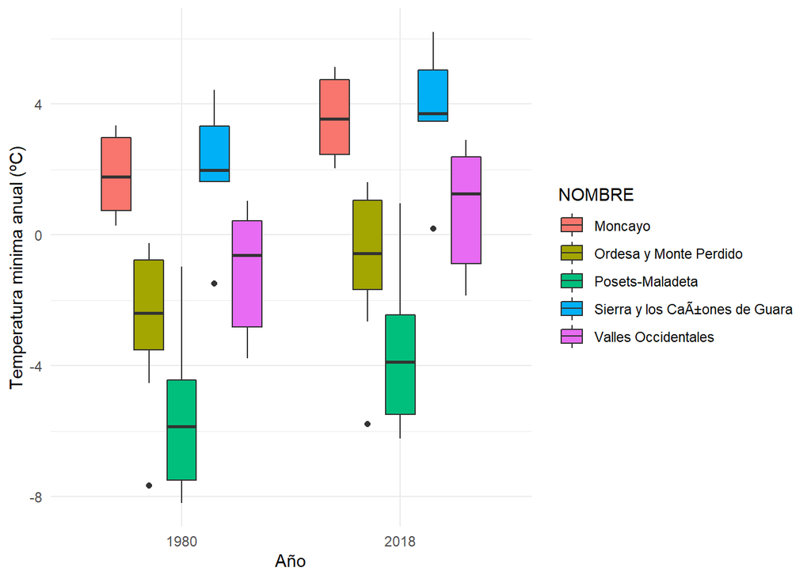

```r
ggplot(Temperatura_minima_anual_PA, aes(x = variable, y = value)) +
  geom_boxplot(aes(fill = NOMBRE)) +
  scale_x_discrete(labels= c("1980", "2018")) +
  scale_colour_brewer(palette = "Dark2") +
  labs(y = "Temperatura minima anual (ºC)", x = "Año") +
  theme_minimal()
```

Tambien es posible generar gráficos combinados, donde se combinen varios gráficos independientes.

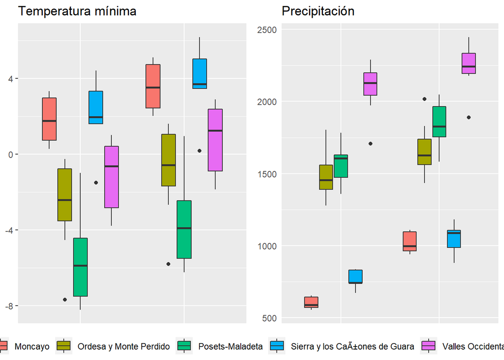

```r
Grafico_temperatura <- ggplot(Temperatura_minima_anual_PA, aes(x = variable, y = value)) +
  geom_boxplot(aes(fill = NOMBRE)) +
  scale_x_discrete(labels= c("1980", "2018")) +
  scale_colour_brewer(palette = "Dark2") +
  labs(y = "Temperatura minima anual (ºC)", x = "Año") +
  ggtitle("Temperatura mínima") +
  theme(
    legend.title = element_blank(),
    axis.title.x = element_blank(),
    axis.text.x = element_blank(),
    axis.title.y = element_blank(),
    axis.ticks.x = element_blank()
  )
Grafico_precipitacion <- ggplot(Precipitacion_anual_PA, aes(x = variable, y = value)) +
  geom_boxplot(aes(fill = NOMBRE)) +
  scale_x_discrete(labels= c("1980", "2018")) +
  scale_colour_brewer(palette = "Dark2") +
  labs(y = "Precipitación anual (mm)", x = "Año") +
  ggtitle("Precipitación") +
  theme(
    legend.title = element_blank(),
    axis.title.x = element_blank(),
    axis.text.x = element_blank(),
    axis.ticks.x = element_blank(),
    axis.title.y = element_blank(),
    axis.ticks.y = element_blank()
  )
ggpubr::ggarrange(Grafico_temperatura, Grafico_precipitacion, common.legend = TRUE, legend = "bottom")
```

# Ejercicio práctica 1

Estos son los pasos sugeridos:  
- Cargar la capa `tmax_aragon_1_2012.tif` generada en la práctica 1.  
- Modificar datos para poder realizar un diagrama de cajas.  
- Graficar.  
El gráfico final a obtener:

[figure not shown]

Solución:

```r
Temperatura_maxima <- raster("E:/SEMINARIO_BIOGEOGRAFIA/RESULTADOS/PRACTICA_1/tmax_aragon_1_2012.tif")
Temperatura_maxima_PA <- extract(Temperatura_maxima, puntos_PA_aragon, fun = mean, df = T)
Temperatura_maxima_PA <- cbind(Temperatura_maxima_PA, puntos_PA_aragon@data)
Temperatura_maxima_PA <- Temperatura_maxima_PA[,c(11,10, 2)]
colnames(Temperatura_maxima_PA) <- c("Nombre", "Figura", "Tmax_1_2012")

Temperatura_maxima_PA <- reshape2::melt(Temperatura_maxima_PA)

ggplot(Temperatura_maxima_PA, aes(x = variable, y = value)) +
  geom_boxplot(aes(fill = Figura)) +
  labs(y = "Temperatura máxima (ºC)") +
  ggtitle("Temperatura máxima (Enero 2012)") +
  theme(
    legend.title = element_blank(),
    axis.title.x = element_blank(),
    axis.text.x = element_blank(),
    axis.ticks.x = element_blank()
  )
```